# Quiz: Simple Linear Regression

## Part One: Twins and IQ

In the mid 20th century, a study was conducted that tracked down identical twins where one child was raised in the home of their biological parents and the other in a foster home. In an attempt to answer the question of whether intelligence is result of nature or nurture, both children were given IQ tests. You can load in the data with the following command:

```r
twins <- read.csv("http://andrewpbray.github.io/data/twins.csv")
```

The IQ of the fosterer child is recorded in `Foster`, the IQ of the biologically- raised child in `Biological`. The socieoeconomic status of the biological family was also recorded in `Social`.

1. Create a plot of the relationship between the IQs of the two children and describe the relationship in words (there is no clear independent variable here, so just put `Biological` on the x-axis).

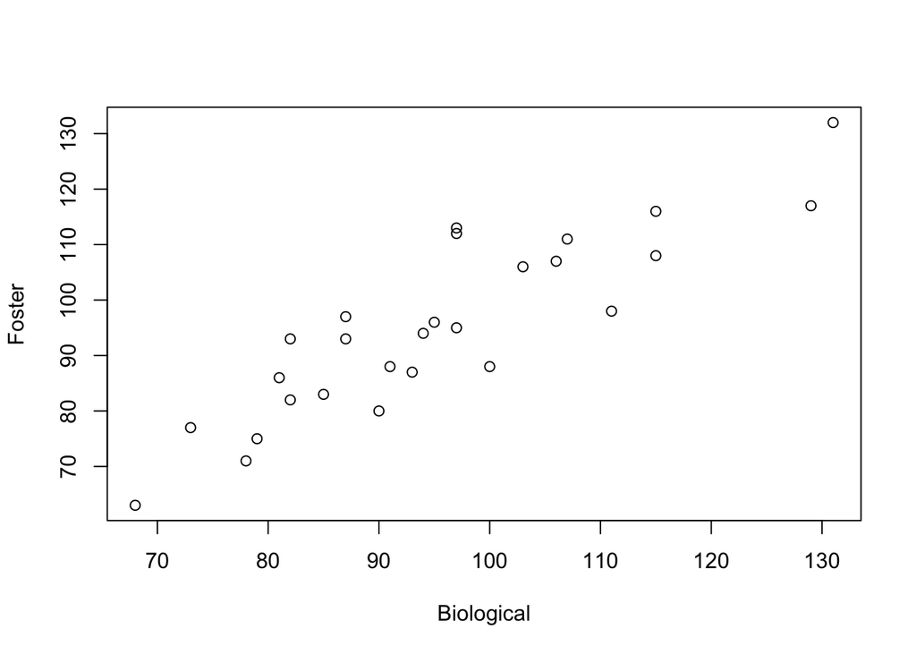

```r
plot(Foster ~ Biological, data = twins)
```

*(2 points) There appears to be a positive linear relationship of moderate strength between the IQ of the biological children and the IQ of the foster children.*

```r
m1 <- lm(Foster ~ Biological, data = twins)
summary(m1)
```

```
##
## Call:
## lm(formula = Foster ~ Biological, data = twins)
##
## Residuals:
##     Min      1Q  Median      3Q     Max
## -11.351  -5.731   0.057   4.324  16.353
##
## Coefficients:
##             Estimate Std. Error t value Pr(>|t|)
## (Intercept)   9.2076     9.2999    0.99     0.33
## Biological    0.9014     0.0963    9.36  1.2e-09 ***
## ---
## Signif. codes:  0 '***' 0.001 '**' 0.01 '*' 0.05 '.' 0.1 ' ' 1
##
## Residual standard error: 7.73 on 25 degrees of freedom
## Multiple R-squared:  0.778,  Adjusted R-squared:  0.769
## F-statistic: 87.6 on 1 and 25 DF,  p-value: 1.2e-09
```

3. Is it reasonable to draw conclusions from this model? Please assess the conditions for a valid model.

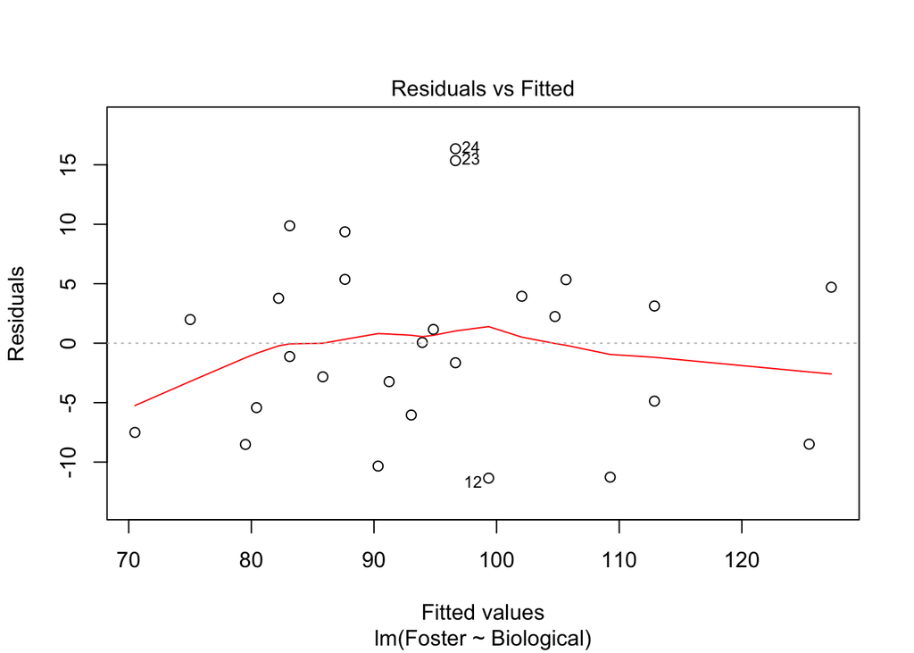

```r
plot(m1, 1)
```

*(3 points) We use the residual vs fitted plot to investigate whether the linear trend assumption seems reasonable. Although the red line has a suggestion of a quadratic trend, it is slight and is susceptible to variation towards the edges where there isn’t much data. The linear trend assumption is probably fine.*

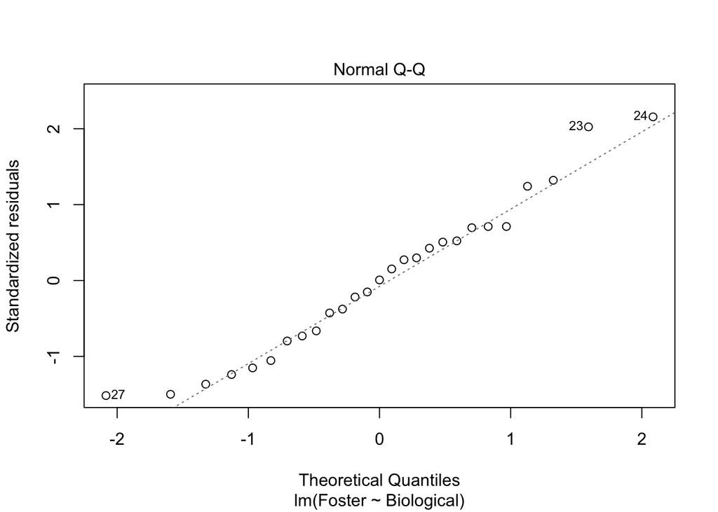

```r
plot(m1, 2)
```

*We use the QQ plot to assess whether it’s reasonable to assume that the errors are normally distributed. As the points follow the identity line quite well, this is a reasonable assumption.*

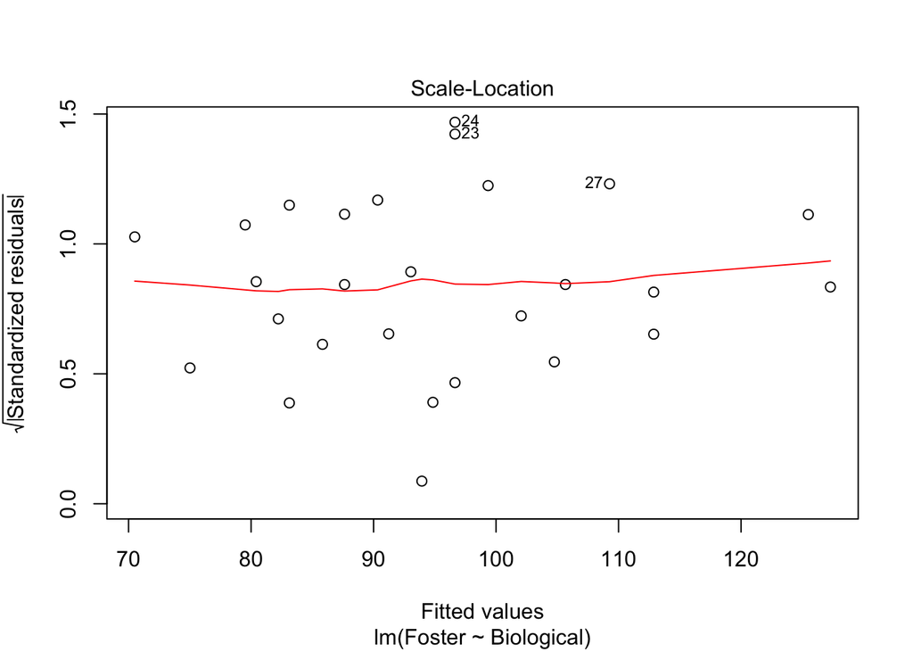

```r
plot(m1, 3)
```

*The scale-location plot is used to assess the constant variance assumption. There is no evidence of non-constant variance based on this plot.*

*The assumption of independent errors appears reasonable since it’s difficult to think of a scenario where twin pairs would be dependent. One possibility that we would want to rule out is that we don’t have pairs with foster or biological members that were raised in the same family (a foster family with two twins, for example).*

*In sum, though we might want to consider a quadratic model for comparison, this appears to be a valid model to draw inferences from. You were not required to comment on influential observations for this quiz, but if you did:*

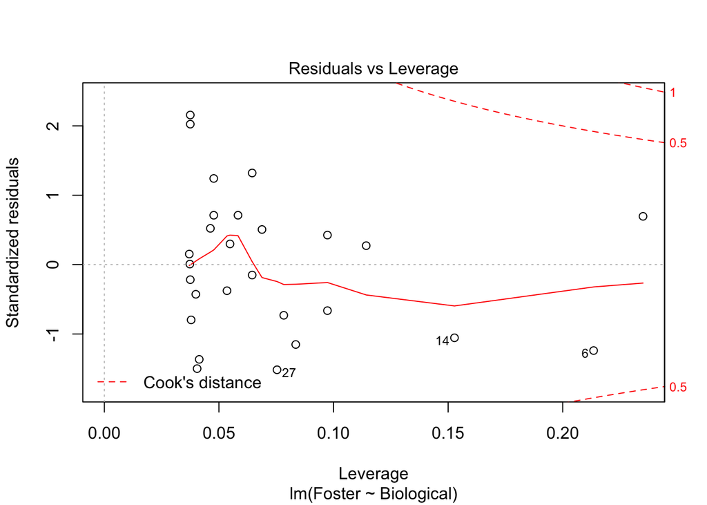

```r
plot(m1, 5)
```

*None of our observations have usually high influence, so that is not a concern here.*

4. This study was used to weigh in on the question of whether IQ is a result of nature (your genes) or nurture (your environment). If IQ was purely a result of nurture, what slope would you expect to see in your linear model? Phrase that hypothetical question in terms of a hypothesis test and interpret the p-value in the context of this problem.

```r
summary(m1)
```

```
##
## Call:
## lm(formula = Foster ~ Biological, data = twins)
##
## Residuals:
##     Min      1Q  Median      3Q     Max
## -11.351  -5.731   0.057   4.324  16.353
##
## Coefficients:
##             Estimate Std. Error t value Pr(>|t|)
## (Intercept)   9.2076     9.2999    0.99     0.33
## Biological    0.9014     0.0963    9.36  1.2e-09 ***
## ---
## Signif. codes:  0 '***' 0.001 '**' 0.01 '*' 0.05 '.' 0.1 ' ' 1
##
## Residual standard error: 7.73 on 25 degrees of freedom
## Multiple R-squared:  0.778,  Adjusted R-squared:  0.769
## F-statistic: 87.6 on 1 and 25 DF,  p-value: 1.2e-09
```

*(3 points) If IQ was a result purely of nuture, then we would expect a slope of zero. In testing terms, $H_0: \beta_1 = 0$, $H_A: \beta_1 \ne 0$. The regression output tests this hypothesis by default, yielding a p-value of 1.2036 × 10<sup>-9</sup>. As a result, we reject that null hypothesis and conclude that Biological IQ can be considered a significant predictor of Foster IQ. This refutes the more general hypothesis that IQ is entirely determined by your environment.*

5. At the other end of the argument, the distribution of IQ might be entirely determined by genes. Use a 95% confidence interval on your slope to assess whether this claim is reasonable given your data set.

```r
ci <- confint(m1, "Biological")
```

*(3 points) The confidence interval for the slope is (0.703, 1.0998). Because it includes 1, this data is consistent with the argument that the distribution of IQ is entirely due to genes.*

6. Now consider how the association between IQs would change if social class were taken into account. Create a plot that illustrates the relationship between all three variables. Just by looking at the plot (and without fitting any models), does it appear that the relationship between the IQs is the same for high social class children as it is for low social class children?

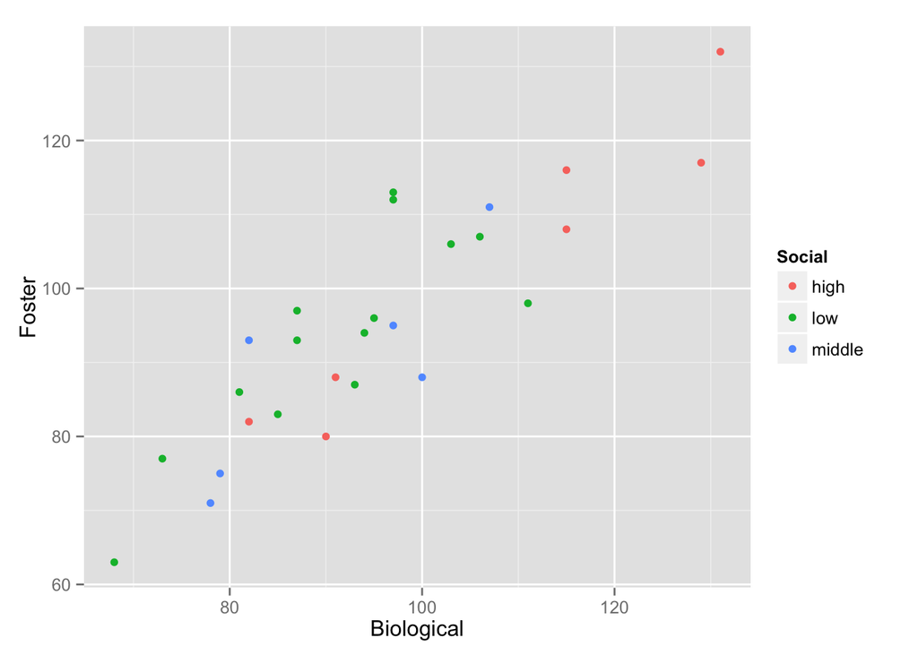

```r
require(ggplot2)
ggplot(twins, aes(x = Biological, y = Foster, color = Social)) + geom_point()
```

*(2 points) If we imagine drawing the identity line through this plot, which represents equity between biological and foster IQs, we see that in most twin pairs with biological parents of low social class, the foster child outperforms the biological child. In pairs with parents biological parents of high social class, there is closer parity. It looks feasible that the relationship between the two is IQs is the the same for both classes (i.e. the slopes), but that the baseline IQ is different(i.e. the intercepts).*

**Endnote**: The researcher that collected this data was named [Cyril Burt](http://en.wikipedia.org/wiki/Cyril_Burt), and his work was the subject of some controversy.

## Part Two: Education and Ethnicity in LA

Researchers in demography were interested in capturing the relationship between the ethnic make up of neighborhoods and the level of education. To gather data they took a random sample of 100 neighborhoods and recorded the proportion of residents in each that identified as hispanic and the proportion of residents that had graduated from college. The data can be loaded with the following command:

```r
LA <- read.csv("http://andrewpbray.github.io/data/LAed.csv")
```

1. Plot the relationship between ethnicity and education, keeping in mind the norm of putting the independent variable on the x-axis. Please describe the structure in the plot as well as any unusual observations.

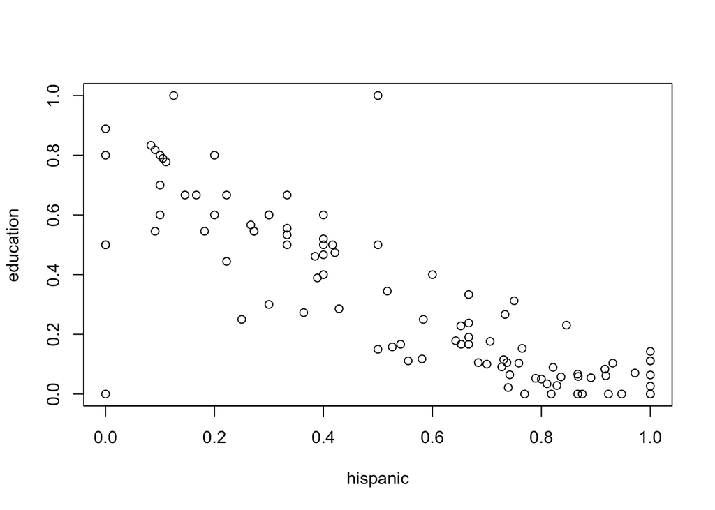

```r
plot(education ~ hispanic, data = LA)
```

*(2 points) There is a negative linear trend of moderate strength between the proportion of hispanic residents in a neighborhood and the proportion of residents that have graduated from college. There are several unusual observations. There is an observation that appears to have a zero recorded for both variables, suggesting either a typo or the inclusion of a neighborhood without any residents. There is also a high outlier with around half hispanic residents but with an education proportion around 1. It is surprising that there are neighborhoods, sometimes several, that register as 0’s or 1’s on one of these metrics.*

2. Fit a linear model to this scatterplot. Have you found a predictor that is statistically significant? In your regression output, what do you look for as evidence and how do you interpret it?

```r
m2 <- lm(education ~ hispanic, data = LA)
summary(m2)
```

```
##
## Call:
## lm(formula = education ~ hispanic, data = LA)
##
## Residuals:
##     Min      1Q  Median      3Q     Max
## -0.7290 -0.0768  0.0023  0.0853  0.6473
##
## Coefficients:
##             Estimate Std. Error t value Pr(>|t|)
## (Intercept)   0.7290     0.0308    23.7   <2e-16 ***
## hispanic     -0.7527     0.0501   -15.0   <2e-16 ***
## ---
## Signif. codes:  0 '***' 0.001 '**' 0.01 '*' 0.05 '.' 0.1 ' ' 1
##
## Residual standard error: 0.152 on 98 degrees of freedom
## Multiple R-squared:  0.697,  Adjusted R-squared:  0.694
## F-statistic:  225 on 1 and 98 DF,  p-value: <2e-16
```

*(3 points) A predictor that is statistically significant is one that has a non-zero slope. This is tested by default by running `summary(m2)`, where $H_0: \beta_1 = 0$, $H_A: \beta_1 \ne 0$. The test yielded a p-value of 3.82 × 10<sup>-27</sup>, which leads to us rejecting the null hypothesis and concluding that the proportion of hispanic residents is a significant predictor of the education level.*

3. Was your inference conclusion based on a valid model? Please use plots to assess the conditions for regression.

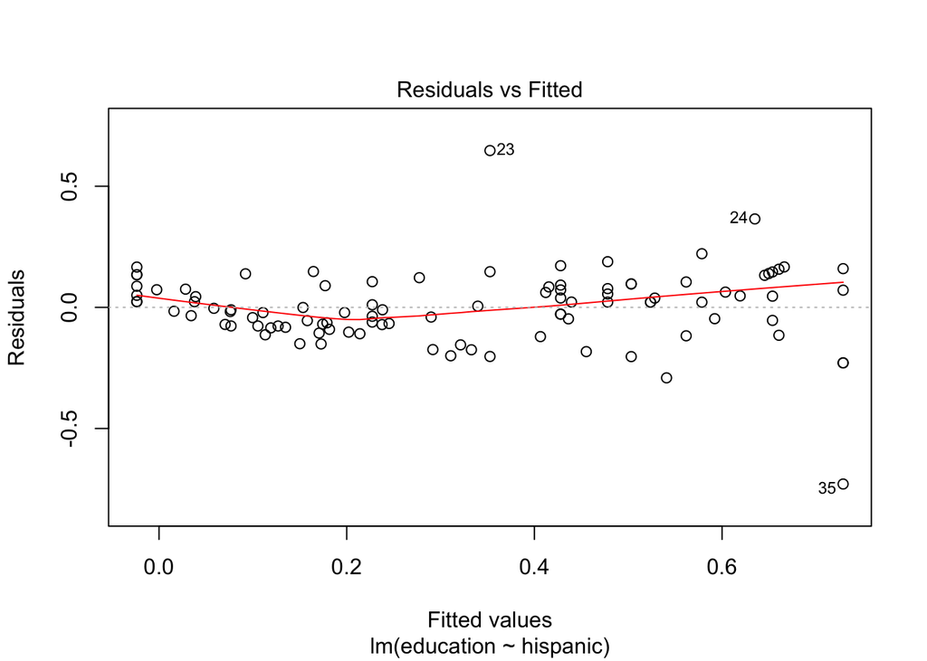

```r
plot(m2, 1)
```

*The assumption of linearity seems reasonable, however there is the possibility that a quadratic model would yield a better fit. We would also want to re-evaulate after investigating the influential points.*

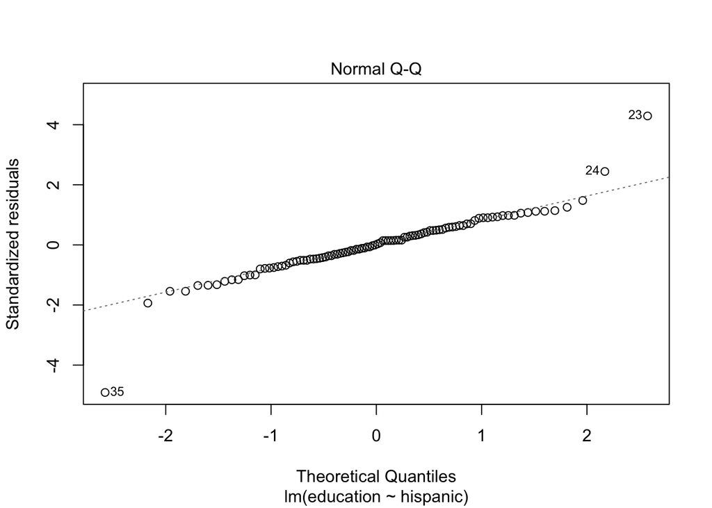

```r
plot(m2, 2)
```

*With the exception of three outliers in the tails, the QQ plot shows that the residuals follow a nearly normal distribution.*

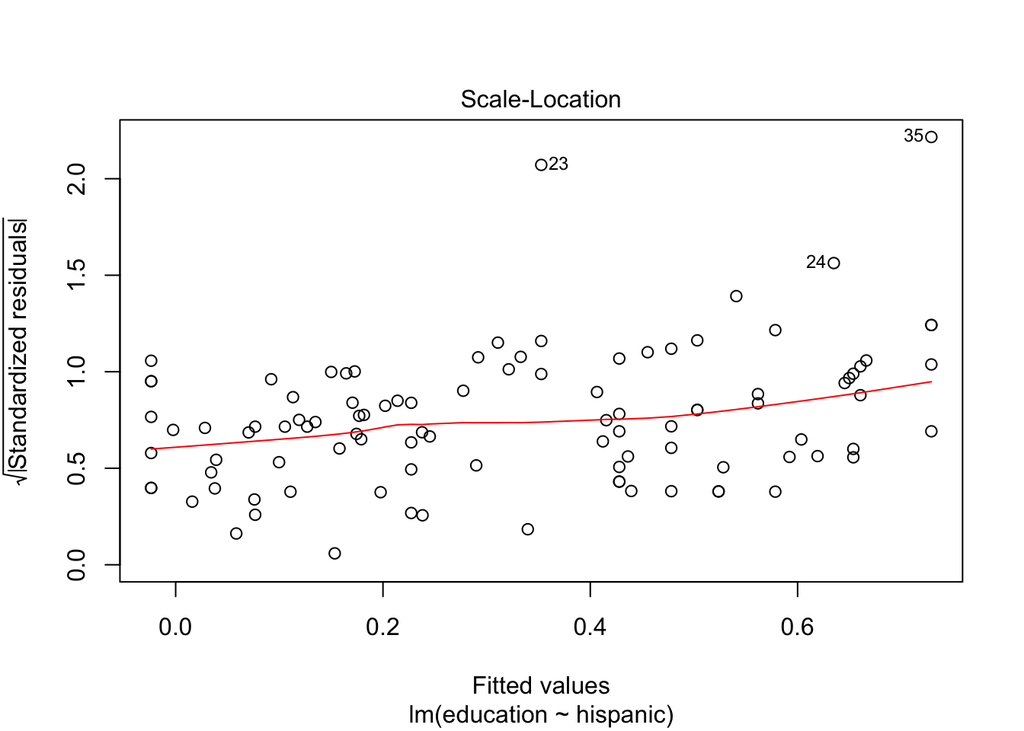

```r
plot(m2, 3)
```

*There is evidence of slightly increasing variance.*

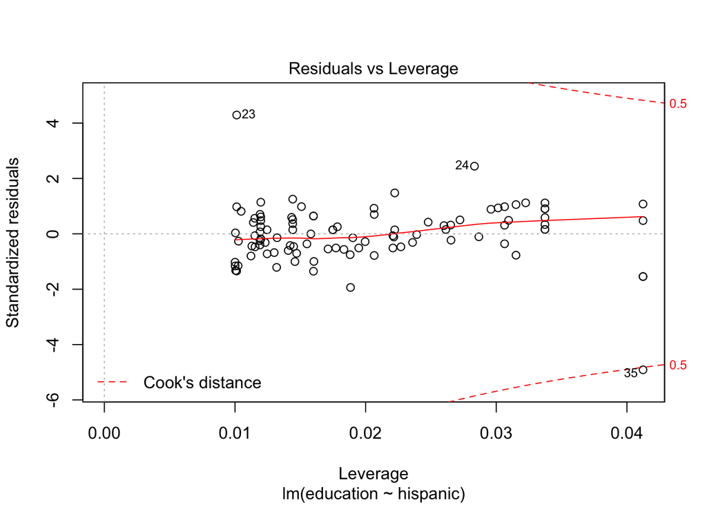

```r
plot(m2, 5)
```

*Observation 35 is flagged as being an influential point. We will want to consider if it appears to be a valid datum and if it belongs in this analysis.*

*In summary, the most apparent issue is some increasing variance in the residuals, though it is not dramatic. There is also some evidence of a quadratic trend and one influential point (thought that need not be noted for this quiz).*

4. Say you work in state program that works to improve the number of under- represented individuals who graduate from college. You are deployed to one of a 20 neighborhoods (not in this sample) in LA that is half hispanic. You’d like to get a sense of the range in the graduation rate for such a neighborhood. Please create the appropriate interval to capture that variation.

```r
pi <- predict(m2, data.frame("hispanic" = .5), interval = "prediction")
```

*We can capture most of the variation in the education level for a neighborhood with 50% hispanic residents by constructing a 95% prediction interval: (0.0503, 0.6551).*

#### Optional challenge Problem

[This is a more challenging problem that will stretch your ability. Don’t let it frustrate you too much, but if you’d like, give it the old college try. You can turn in paper and pencil work under my office door by Friday evening if you’re old school like that.]

Number 4 from the end of Chapter 2 exercises.